# Almond Yield Model, Group C

# Setup

```r
# Read in climate data
clim <- read_delim("./clim.txt", delim=" ")
```

# Assignment 2 - Almond Yield Function

## Compute Yield

```r
model_results <- yield_model(clim)

kable(model_results %>%
        rename(Year = year, "Almond Yield Anomaly (ton/acre)" = almond_yield),
      digits=4,
      caption = "Modeled Almond Yield Anomaly 1989-2010",
      format = "html",
      table.attr = "style='width:50%;'") %>%
  kable_classic() %>%
  kable_styling(bootstrap_options = c("striped", "hover"),
                position = "left"
                )
```

Modeled Almond Yield Anomaly 1989-2010

| Year | Almond Yield Anomaly (ton/acre) |
| --- | --- |
| 1988 | NaN |
| 1989 | -0.3552 |
| 1990 | 9.2907 |
| 1991 | 68.9131 |
| 1992 | 15.4281 |
| 1993 | 20.2084 |
| 1994 | 2.4820 |
| 1995 | 1919.9812 |
| 1996 | 3.5818 |
| 1997 | 329.6939 |
| 1998 | 27.8637 |
| 1999 | -0.1436 |
| 2000 | 9.6000 |
| 2001 | 159.5120 |
| 2002 | 0.2451 |
| 2003 | -0.2586 |
| 2004 | -0.2368 |
| 2005 | 656.3724 |
| 2006 | 18.6324 |
| 2007 | 20.2007 |
| 2008 | 576.2822 |
| 2009 | 0.7367 |
| 2010 | 153.7655 |

## Visualize Yield

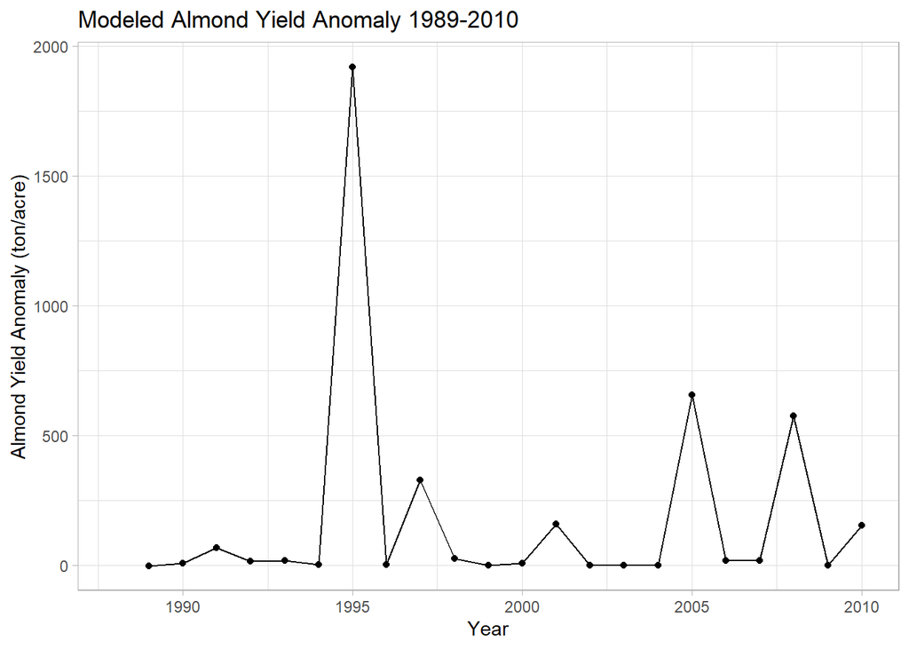

```r
ggplot(data = model_results, aes(x = year, y = almond_yield)) +
  geom_line() +
  geom_point() +
  theme_light() +
  labs(x = "Year",
       y = "Almond Yield Anomaly (ton/acre)",
       title = "Modeled Almond Yield Anomaly 1989-2010")
```

## Additional Exploration

```r
rain <- clim %>%
  group_by(year) %>%
  summarize(sum_precip = sum(precip))

rain_yield <- full_join(model_results, rain)
```

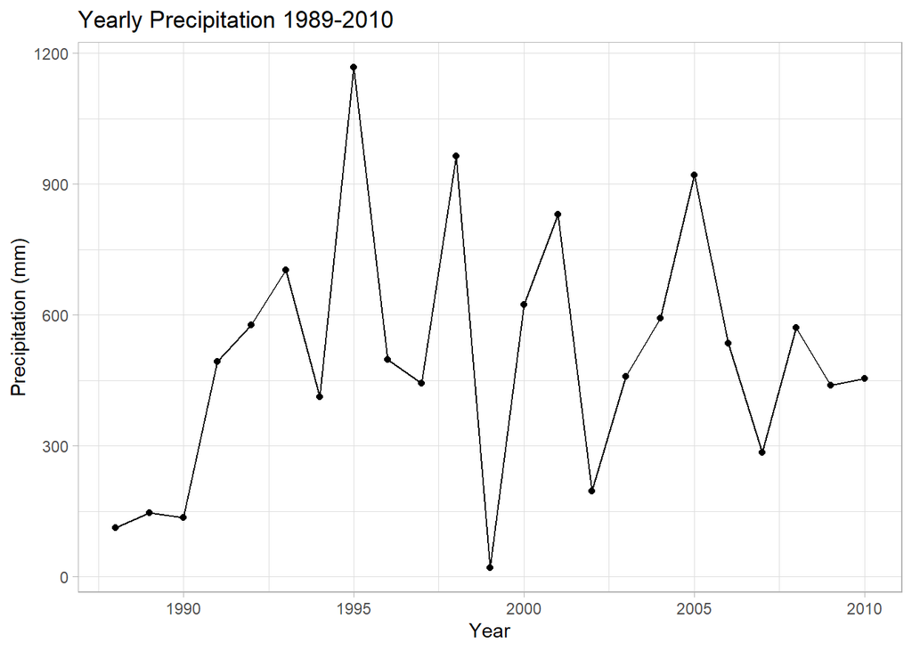

```r
ggplot(data = rain, aes(x = year, y = sum_precip)) +
  geom_line() +
  geom_point() +
  theme_light() +
  labs(x = "Year",
       y = "Precipitation (mm)",
       title = "Yearly Precipitation 1989-2010")
```

```r
linear_model <- lm(data = rain_yield, almond_yield ~ sum_precip)

summary.lm(linear_model)
```

```
##
## Call:
## lm(formula = almond_yield ~ sum_precip, data = rain_yield)
##
## Residuals:
##     Min      1Q  Median      3Q     Max
## -568.51 -207.41  -81.06  158.26 1132.38
##
## Coefficients:
##              Estimate Std. Error t value Pr(>|t|)
## (Intercept) -306.4041   159.4671  -1.921  0.06905 .
## sum_precip     0.9362     0.2707   3.458  0.00248 **
## ---
## Signif. codes:  0 '***' 0.001 '**' 0.01 '*' 0.05 '.' 0.1 ' ' 1
##
## Residual standard error: 348.9 on 20 degrees of freedom
##   (1 observation deleted due to missingness)
## Multiple R-squared:  0.3742, Adjusted R-squared:  0.343
## F-statistic: 11.96 on 1 and 20 DF,  p-value: 0.002482
```

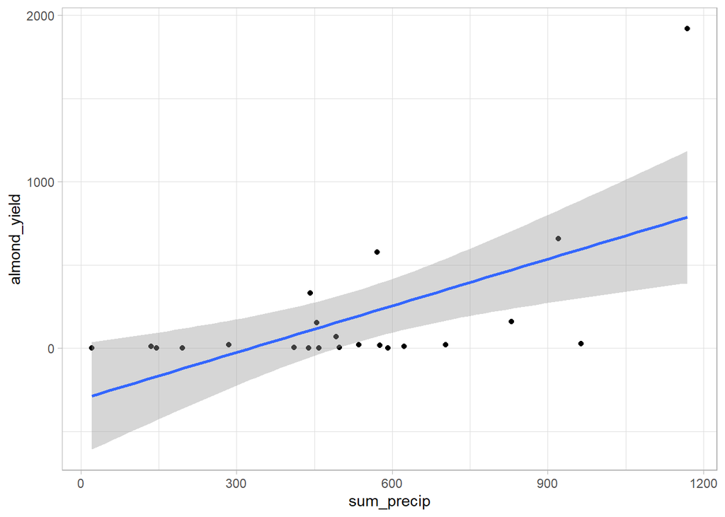

```r
ggplot(data = rain_yield, aes(x = sum_precip, y = almond_yield)) +
  geom_point() +
  geom_smooth(method = "lm") +
  theme_light()
```

Our findings demonstrate four years of almond yields below the anomaly (1989, 1999, 2003, 2004). Noticeable spikes in almond yield occur in 1995, 2005 and 2008. There seems to be a general pattern regarding consecutive years of yields slightly above/below the anomaly with on year spikes occurring every few years. By plotting annual precipitation, we see a similar pattern in the data, with high rainfall generally correlating with high almond yields. The linear regression also supports the correlation.

# Assignment 3 - Almond Profit Sensitivity

## Compute Simple Profit Model

The code below calculates and visualizes profit based on yield results from Assignment 2 using default parameters.

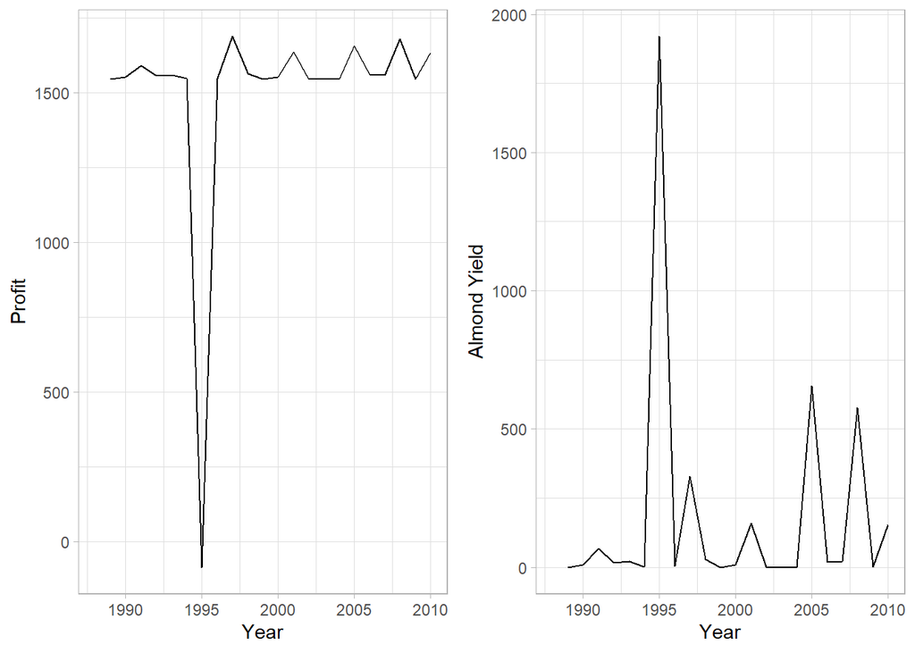

```r
profit <- profit_model(yield_results = model_results)

p1 = ggplot(profit, aes(x=year, y=profit)) +
  geom_line() +
  theme_light() +
  labs(y="Profit", x="Year")

p2 = ggplot(profit, aes(x=year, y=almond_yield)) +
  geom_line() +
  theme_light() +
  labs(y="Almond Yield", x="Year")

ggarrange(p1, p2)
```

## Simple Informal Sensitivity Analysis

The following simple informal sensitivity analysis assumes uncertainty in *temp_param2* and *precip_param2* parameters, with default values from the function -0.0046 and 0.0043, respectively.

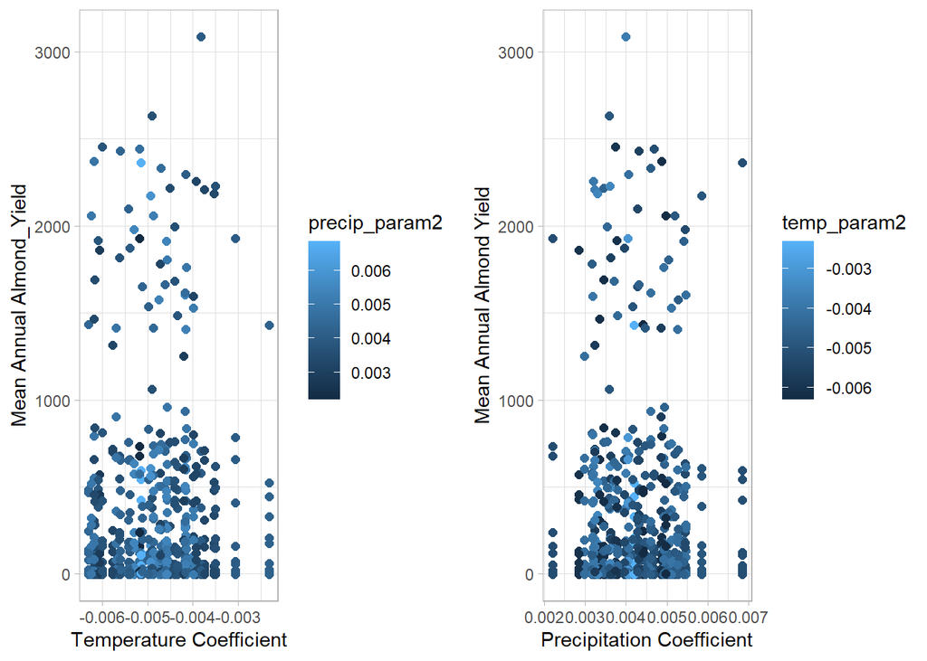

```r
nsamples = 50
deviation = 0.001
base_temp = -0.0046
base_precip = 0.0043

# Create normal distributions of both parameters
temp_param2 = rnorm(mean = base_temp, sd = deviation, n = nsamples)
precip_param2 = rnorm(mean = base_precip, sd = deviation, n = nsamples)

# Combine into data frame
params = cbind.data.frame(temp_param2, precip_param2)

# Run yield model on all parameter combinations
results = params %>% pmap(yield_model, clim=clim,
                          temp_param=-0.015, precip_param=-0.07, intercept=0.28,
                          year_start=min(clim$year), year_end=max(clim$year))

# Extract results
mean_yield = map_df(results, `[`, c("year", "almond_yield"))
mean_yield = cbind.data.frame(mean_yield, params)

# Plot results
p1 = ggplot(mean_yield,
            aes(temp_param2, almond_yield, col=precip_param2)) +
  geom_point(cex=2) +
  theme_light() +
  labs(y="Mean Annual Almond_Yield",
       x="Temperature Coefficient")

p2 = ggplot(mean_yield,
            aes(precip_param2, almond_yield, col=temp_param2)) +
  geom_point(cex=2) +
  theme_light() +
  labs(y="Mean Annual Almond Yield",
       x="Precipitation Coefficient")

ggarrange(p1, p2)
```

The parameter combinations used for the sensitivity analysis are plotted below.

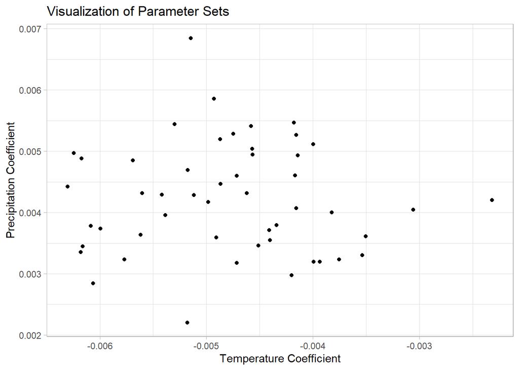

```r
# Investigate parameter space
ggplot(mean_yield, aes(x=temp_param2, y=precip_param2)) +
  geom_point() +
  theme_light() +
  labs(x="Temperature Coefficient",
       y="Precipitation Coefficient",
       title="Visualization of Parameter Sets")
```

## Almond Profit Uncertainty

Using the results from the previous section, we can plot yearly profit distribution given parameter uncertainty.

```r
profit_sensitivity <- profit_model(yield_results = mean_yield)
```

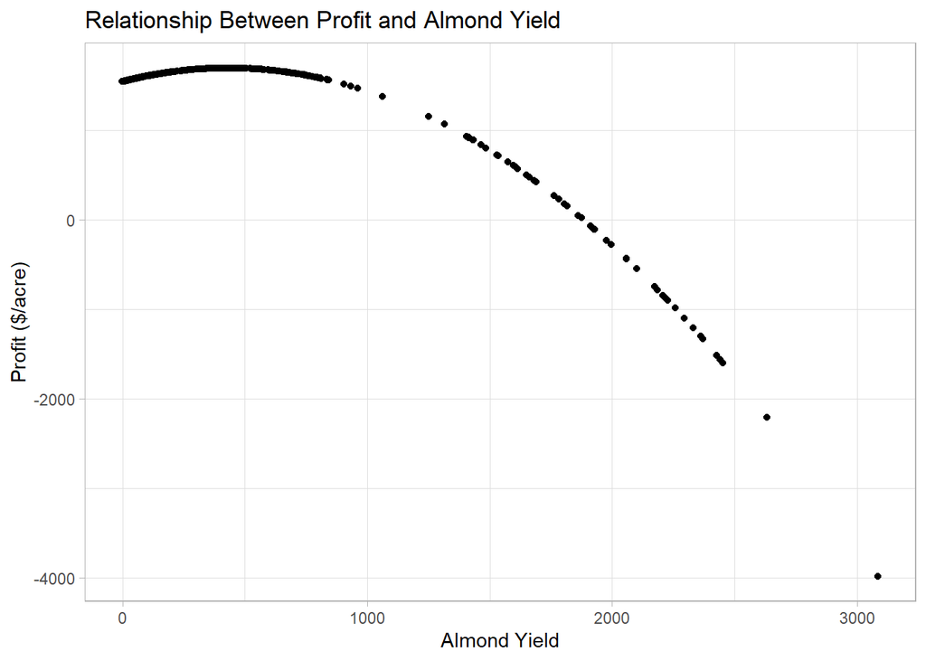

```r
ggplot(profit_sensitivity, aes(x=almond_yield, y=profit)) +
  geom_point() +
  theme_light() +
  labs(x="Almond Yield",
       y="Profit ($/acre)",
       title="Relationship Between Profit and Almond Yield")
```

Lastly, we plot yearly profit distribution given parameter uncertainty. In our submitted graph, 1995 is separated due to the large difference in scale.

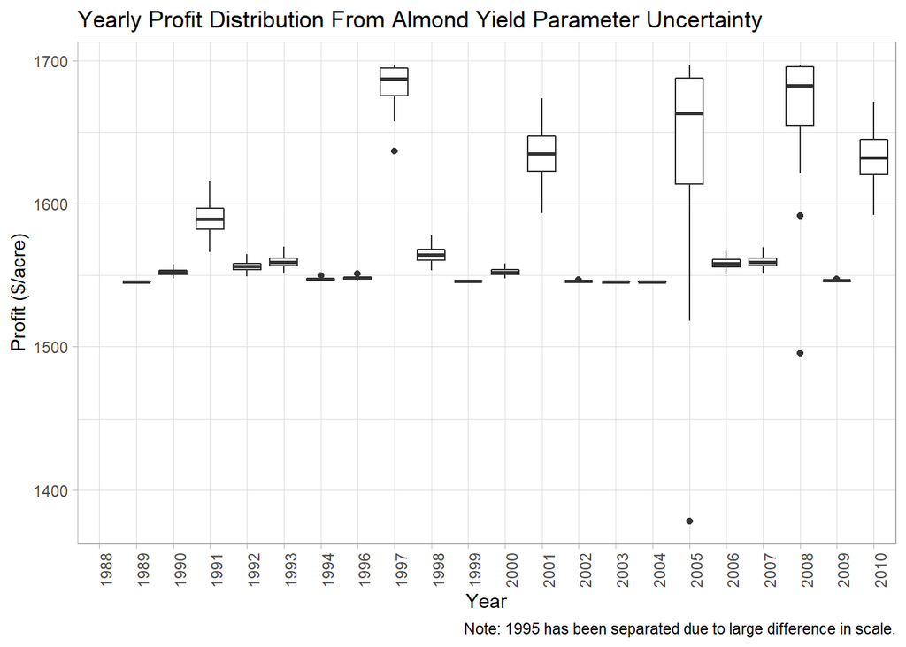

```r
p1 <- profit_sensitivity %>% filter(year != 1995) %>% ggplot(aes(x=factor(year), y=profit, group=year)) +
  geom_boxplot() +
  theme_light() +
  theme(axis.text.x = element_text(angle=90)) +
  labs(x="Year", y="Profit ($/acre)",
       title="Yearly Profit Distribution From Almond Yield Parameter Uncertainty",
       caption="Note: 1995 has been separated due to large difference in scale.")
p1
```

```r
ggsave("profit_sensitivity.jpg", p1)
```

The same plot, with 1995 included, is below.

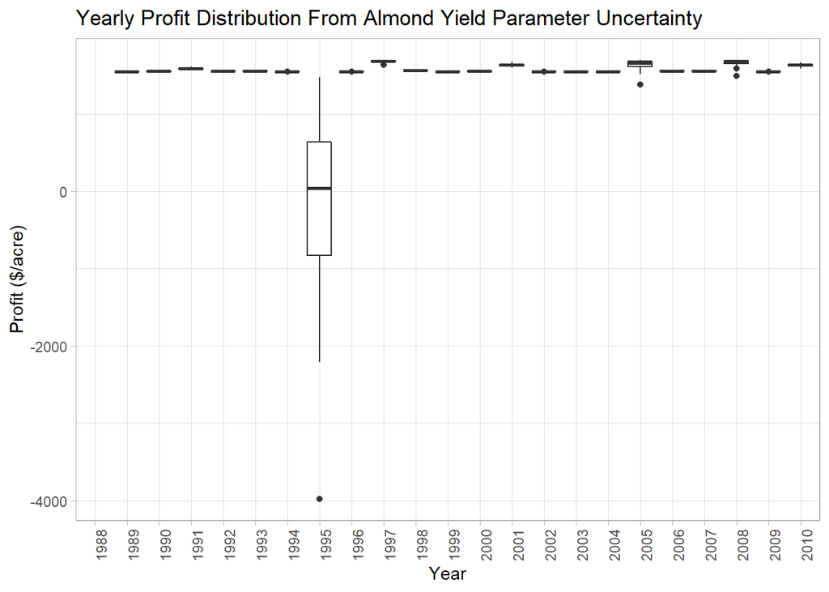

```r
p2 <- profit_sensitivity %>% ggplot(aes(x=factor(year), y=profit, group=year)) +
  geom_boxplot() +
  theme_light() +
  theme(axis.text.x = element_text(angle=90)) +
  labs(x="Year", y="Profit ($/acre)",
       title="Yearly Profit Distribution From Almond Yield Parameter Uncertainty")
p2
```